# Assignment_4

## Data Cleaning/Data Mining

###### - Import python libraries.

- Load the attached dataset.
- Explore the data and check number of (rows & columns).
- Check if there is any missing values and handle it.
- Check the datatype of each column
- Check if there is any duplicate values and remove it using (df.drop_duplicates(inplace=True))

```python
import pandas as pd
import numpy as np
import matplotlib.pyplot as plt
```

```python
data=pd.read_excel(r"D:\Training Doucments\2021_11_16_Machine Learning using Python\Assignments\Assignment_4\ccpp.xlsx")
```

```python
data
```

|  | AT | V | AP | RH | PE |
| --- | --- | --- | --- | --- | --- |
| 0 | 14.96 | 41.76 | 1024.07 | 73.17 | 463.26 |
| 1 | 25.18 | 62.96 | 1020.04 | 59.08 | 444.37 |
| 2 | 5.11 | 39.40 | 1012.16 | 92.14 | 488.56 |
| 3 | 20.86 | 57.32 | 1010.24 | 76.64 | 446.48 |
| 4 | 10.82 | 37.50 | 1009.23 | 96.62 | 473.90 |
| ... | ... | ... | ... | ... | ... |
| 9563 | 16.65 | 49.69 | 1014.01 | 91.00 | 460.03 |
| 9564 | 13.19 | 39.18 | 1023.67 | 66.78 | 469.62 |
| 9565 | 31.32 | 74.33 | 1012.92 | 36.48 | 429.57 |
| 9566 | 24.48 | 69.45 | 1013.86 | 62.39 | 435.74 |
| 9567 | 21.60 | 62.52 | 1017.23 | 67.87 | 453.28 |

9568 rows × 5 columns

```python
data.info()
```

```
<class 'pandas.core.frame.DataFrame'>
RangeIndex: 9568 entries, 0 to 9567
Data columns (total 5 columns):
 #   Column  Non-Null Count  Dtype
---  ------  --------------  -----
 0   AT      9568 non-null   float64
 1   V       9568 non-null   float64
 2   AP      9568 non-null   float64
 3   RH      9568 non-null   float64
 4   PE      9568 non-null   float64
dtypes: float64(5)
memory usage: 373.9 KB
```

```python
data.isnull().sum()
```

```
AT    0
V     0
AP    0
RH    0
PE    0
dtype: int64
```

```python
data.drop_duplicates(inplace=True)
```

```python
data.info()
```

```
<class 'pandas.core.frame.DataFrame'>
Int64Index: 9527 entries, 0 to 9567
Data columns (total 5 columns):
 #   Column  Non-Null Count  Dtype
---  ------  --------------  -----
 0   AT      9527 non-null   float64
 1   V       9527 non-null   float64
 2   AP      9527 non-null   float64
 3   RH      9527 non-null   float64
 4   PE      9527 non-null   float64
dtypes: float64(5)
memory usage: 446.6 KB
```

```python
duplicate_values=9568-9527
```

```python
duplicate_values
```

```
41
```

## Feature Extraction and visualization

-Check the distribution of the variables using (df.describe) and check the standard deviation -Determine which features will help to predict the output power using Correlation coefficient (r), Use the following code to check the correlation coefficient (r). import seaborn as sns plt.figure(figsize = (7, 5)) sns.heatmap(df.corr(), annot = True)

Tip: Correlation is measured on a scale of (-1 to 1). -1 means complete negative correlation and 1 means complete positive correlation. 0 means no correlation at all.

From the above which variable have strong or weak correlation with the target variable?

- Strong Correlation variable: V& AT
- Weak Correlation variable :RH & AP

Tip: We can visualize the distribution of the dataset (which shows how each feature correlates to each other and the PE) using the following code: import seaborn as sns sns.set(style=”ticks”) sns.pairplot(df, diag_kind = ‘hist’)

Caution: You will notice some independent variables(x) are highly correlated with each other. This is usually not a good thing as our features should be independent of each other. This problem is called multicollinearity, in this case we need to remove one of these variables which have less correlation with the target variable.

```python
data.describe()
```

|  | AT | V | AP | RH | PE |
| --- | --- | --- | --- | --- | --- |
| count | 9527.000000 | 9527.000000 | 9527.000000 | 9527.000000 | 9527.00000 |
| mean | 19.658225 | 54.293421 | 1013.237084 | 73.334951 | 454.33591 |
| std | 7.444397 | 12.686309 | 5.940526 | 14.607513 | 17.03908 |
| min | 1.810000 | 25.360000 | 992.890000 | 25.560000 | 420.26000 |
| 25% | 13.530000 | 41.740000 | 1009.085000 | 63.375000 | 439.75000 |
| 50% | 20.350000 | 52.080000 | 1012.920000 | 75.000000 | 451.52000 |
| 75% | 25.710000 | 66.510000 | 1017.200000 | 84.850000 | 468.36500 |
| max | 37.110000 | 81.560000 | 1033.300000 | 100.160000 | 495.76000 |

```python
data.corr()
```

|  | AT | V | AP | RH | PE |
| --- | --- | --- | --- | --- | --- |
| AT | 1.000000 | 0.843689 | -0.508222 | -0.543947 | -0.947908 |
| V | 0.843689 | 1.000000 | -0.415718 | -0.312214 | -0.869900 |
| AP | -0.508222 | -0.415718 | 1.000000 | 0.101631 | 0.518687 |
| RH | -0.543947 | -0.312214 | 0.101631 | 1.000000 | 0.391175 |
| PE | -0.947908 | -0.869900 | 0.518687 | 0.391175 | 1.000000 |

```python
import seaborn as sns
```

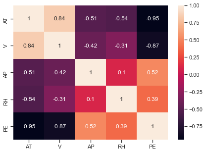

```python
plt.figure(figsize = (7, 5))
sns.heatmap(data.corr(), annot = True)
```

```python
#Which variables are correlated with each other’s? V & AT, V has less correction with PE for that will be remove
```

```python
data2=data.copy()
```

```python
data2.drop(labels=["V"],inplace=True,axis=1)
```

```python
data2.head()
```

|  | AT | AP | RH | PE |
| --- | --- | --- | --- | --- |
| 0 | 14.96 | 1024.07 | 73.17 | 463.26 |
| 1 | 25.18 | 1020.04 | 59.08 | 444.37 |
| 2 | 5.11 | 1012.16 | 92.14 | 488.56 |
| 3 | 20.86 | 1010.24 | 76.64 | 446.48 |
| 4 | 10.82 | 1009.23 | 96.62 | 473.90 |

```python
#sns.set(style=”ticks”)
sns.set(style='ticks')
```

```
C:\Users\Yasser Al Sharhan\anaconda3\lib\site-packages\seaborn\axisgrid.py:1969: UserWarning: The `size` parameter has been renamed to `height`; please update your code.
  warnings.warn(msg, UserWarning)
```

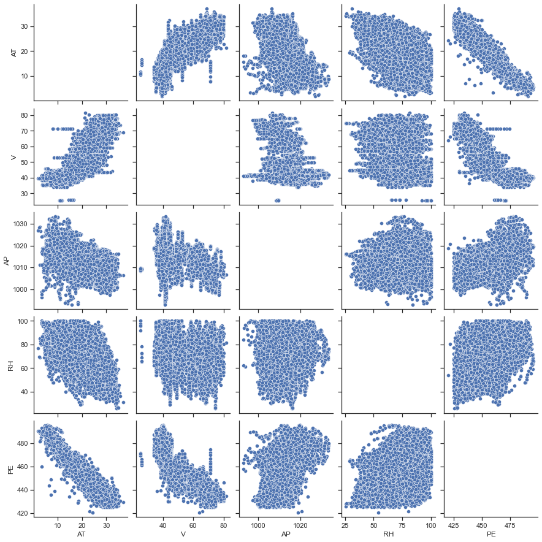

```python
#sns.pairplot(data, diag_kind ='ticks' ‘hist’)
sns.pairplot(data, diag_kind='species', size=2.5)
```

```
C:\Users\Yasser Al Sharhan\anaconda3\lib\site-packages\seaborn\axisgrid.py:1969: UserWarning: The `size` parameter has been renamed to `height`; please update your code.
  warnings.warn(msg, UserWarning)
```

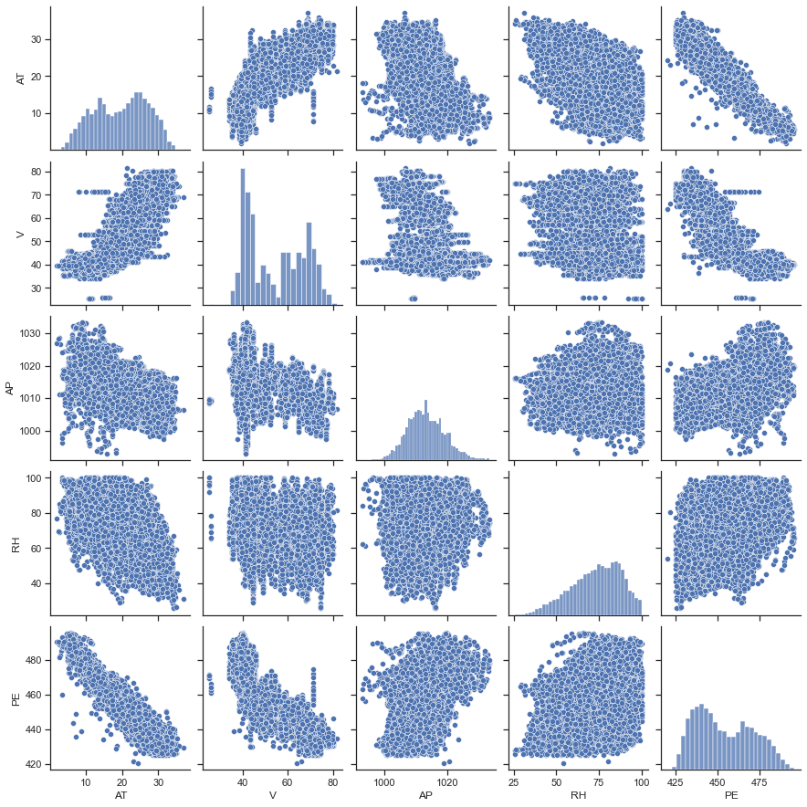

```python
sns.pairplot(data, diag_kind='hist', size=2.5)
```

## Develop the model

##### #

- Divide our data into (x) and (y) using .iloc[row,column]
- Split the data set into training and testing using (train_test_split) with 30 as a ratio
- Create Multiple linear regression model using fit() function

```python
x=data2.iloc[:,:-1].values
y=data2.iloc[:,-1].values
```

```python
x
```

```
array([[  14.96, 1024.07,   73.17],
       [  25.18, 1020.04,   59.08],
       [   5.11, 1012.16,   92.14],
       ...,
       [  31.32, 1012.92,   36.48],
       [  24.48, 1013.86,   62.39],
       [  21.6 , 1017.23,   67.87]])
```

```python
y
```

```
array([463.26, 444.37, 488.56, ..., 429.57, 435.74, 453.28])
```

```python
x.ndim
```

```
2
```

```python
y.ndim
```

```
1
```

```python
from sklearn.model_selection import train_test_split
```

```python
xtrain,xtest,ytrain,ytest=train_test_split(x,y,test_size=0.3,random_state=123)
```

```python
xtrain
```

```
array([[   9.45, 1023.08,   75.81],
       [  17.43, 1019.87,   92.77],
       [  19.83, 1019.81,   75.05],
       ...,
       [  23.14, 1008.89,   81.82],
       [  19.09, 1015.58,   92.56],
       [  24.26, 1008.48,   66.74]])
```

```python
xtest
```

```
array([[  23.48, 1015.82,   60.83],
       [  23.04, 1011.23,   64.27],
       [  30.68, 1005.63,   57.05],
       ...,
       [  15.  , 1015.57,   64.82],
       [  25.04, 1006.82,   84.75],
       [  26.6 , 1010.26,   66.16]])
```

```python
ytrain
```

```
array([483.66, 449.36, 448.03, ..., 444.51, 449.24, 437.4 ])
```

```python
ytest
```

```
array([445.66, 442.01, 429.64, ..., 468.72, 433.1 , 436.19])
```

```python
from sklearn.linear_model import LinearRegression
```

```python
model=LinearRegression()
```

```python
model.fit(xtrain,ytrain)
```

```
LinearRegression()
```

```python
model.predict(xtest)
```

```
array([447.89448903, 448.1102432 , 431.29902836, ..., 467.20267672,
       439.04905136, 439.24531728])
```

## Evaluate the model

```python
model.coef_
```

```
array([-2.37405246,  0.02711304, -0.20476164])
```

```python
# y= x1m1 + x2m2 + x3m3 + b
```

```python
model.intercept_
```

```
488.55091832242755
```

```python
model.score(xtest,ytest)
```

```
0.9145250848471939
```

```python
model.score(xtrain,ytrain)
```

```
0.9230861142611261
```

```python
ypred=model.predict(xtest)
```

```python
ypred
```

```
array([447.89448903, 448.1102432 , 431.29902836, ..., 467.20267672,
       439.04905136, 439.24531728])
```

```python
data
```

|  | AT | V | AP | RH | PE |
| --- | --- | --- | --- | --- | --- |
| 0 | 14.96 | 41.76 | 1024.07 | 73.17 | 463.26 |
| 1 | 25.18 | 62.96 | 1020.04 | 59.08 | 444.37 |
| 2 | 5.11 | 39.40 | 1012.16 | 92.14 | 488.56 |
| 3 | 20.86 | 57.32 | 1010.24 | 76.64 | 446.48 |
| 4 | 10.82 | 37.50 | 1009.23 | 96.62 | 473.90 |
| ... | ... | ... | ... | ... | ... |
| 9563 | 16.65 | 49.69 | 1014.01 | 91.00 | 460.03 |
| 9564 | 13.19 | 39.18 | 1023.67 | 66.78 | 469.62 |
| 9565 | 31.32 | 74.33 | 1012.92 | 36.48 | 429.57 |
| 9566 | 24.48 | 69.45 | 1013.86 | 62.39 | 435.74 |
| 9567 | 21.60 | 62.52 | 1017.23 | 67.87 | 453.28 |

9527 rows × 5 columns

```python
data3['Y-Pred'] = ypred
```

```python
data3
```

|  | 0 | Y-Pred |
| --- | --- | --- |
| 0 | 447.894489 | 447.894489 |
| 1 | 448.110243 | 448.110243 |
| 2 | 431.299028 | 431.299028 |
| 3 | 450.678629 | 450.678629 |
| 4 | 433.261524 | 433.261524 |
| ... | ... | ... |
| 2854 | 467.817135 | 467.817135 |
| 2855 | 444.697722 | 444.697722 |
| 2856 | 467.202677 | 467.202677 |
| 2857 | 439.049051 | 439.049051 |
| 2858 | 439.245317 | 439.245317 |

2859 rows × 2 columns

```python
ypred.predict([[22.1,71.29,1008.2,75.38]])
```

[output not shown]